# Merced River

Sadie Gill, Mark Tompkins

July 2020

## Future Data Improvements

None planned.

## Instream Spawning and Rearing Habitat

**Data Source:** [Merced Irrigation District 2013](https://cvpiahabitat-r-package.s3-us-west-2.amazonaws.com/cvpia-sit-model-inputs/MID2013_MercedIFIMStudy.pdf) (pg 67-75)

Instream spawning and rearing habitat for Fall Run Chinook Salmon and Steelhead in the Merced River are based on data from a 2011-2012 Merced Irrigation District flow-habitat study. The study took place along the 19.2 mile section of the Merced River from the Crocker-Huffman Diversion Dam at river mile (RM) 52.01 to the Shaffer Bridge at river mile 32.8. Habitat data from this study are summarized on pages 67 - 75 of the MID 2013 study. The instream Fall Run Chinook Salmon spawning and rearing habitat data were provided to us by Mark Gard from the California Department of Fish and Wildlife in a [spreadsheet](https://cvpiahabitat-r-package.s3-us-west-2.amazonaws.com/IFIMWUA.xlsx). Mark Gard instructed us to use A51:D81, A84:D114, and A117:D147 of the ‘Merced’ tab within the spreadsheet. Steelhead data were also compiled from the Merced Irrigation District 2013 study. The three study reaches for both Fall Run Chinook Salmon and Steelhead were combined and weighted by reach length.

### Spawning and Rearing Data

The instream spawning and rearing habitat data described above for Fall Run Chinook Salmon (FR) and Steelhead (ST) are combined for use in the Decision Support Model (DSM) in the following format. Units are in square feet per 1000 feet.

Header Descriptions: flow_cfs = flow in cubic feet per second, FR_spawn_wua = Fall Run Chinook Spawning WUA, FR_fry_wua = Fall Run Chinook Fry WUA, FR_juv_wua = Fall Run Chinook Juvenile WUA, ST_spawn_wua = Steelhead Spawning WUA, ST_fry_wua = Steelhead Fry WUA, ST_juv_wua = Steelhead Juvenile WUA, ST_adult_wua = Steelhead Adult WUA, watershed = section of stream modeled for CVPIA SDM

| flow_cfs | FR_spawn_wua | FR_fry_wua | FR_juv_wua | ST_spawn_wua | ST_fry_wua | ST_juv_wua | ST_adult_wua | watershed |
| --- | --- | --- | --- | --- | --- | --- | --- | --- |
| 74 | 6841.958 | 27384.44 | 34256.02 | 13979.71 | 29291.27 | 44183.85 | 16939.96 | Merced River |
| 75 | 6872.323 | 27375.00 | 34268.59 | 14015.95 | 29280.04 | 44201.88 | 16965.32 | Merced River |
| 80 | 7326.021 | 27174.50 | 34505.67 | 14580.36 | 29010.03 | 44528.09 | 17541.58 | Merced River |
| 90 | 8244.875 | 26759.67 | 34956.17 | 15714.98 | 28239.46 | 45162.25 | 18712.06 | Merced River |
| 100 | 9027.229 | 26319.10 | 35286.49 | 16783.10 | 27592.16 | 45609.55 | 19750.10 | Merced River |

*… with 60 more rows*

### Spawning WUA

The following plot shows the weighted usable spawning area (WUA) in square feet per thousand feet for Fall Run Chinook Salmon and Steelhead. These area per length rates are multiplied by the total spawning reach length mapped by the Science Integration Team (SIT) to estimate available habitat.

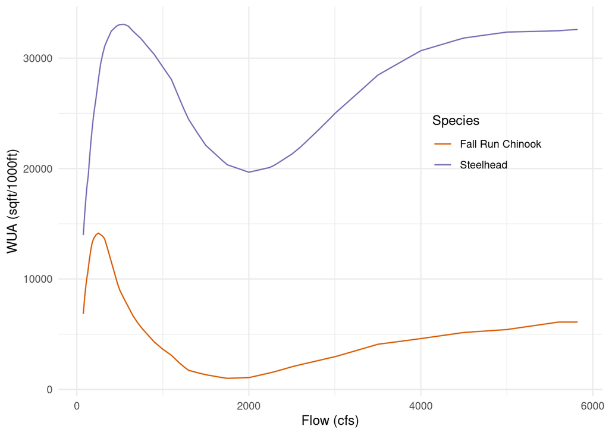

### Rearing WUA

The following plot shows the rearing WUA in square feet per thousand feet for Fall Run Chinook Salmon and Steelhead fry and juvenile. These rates are multiplied by the total rearing reach length mapped by the SIT to estimate available habitat.

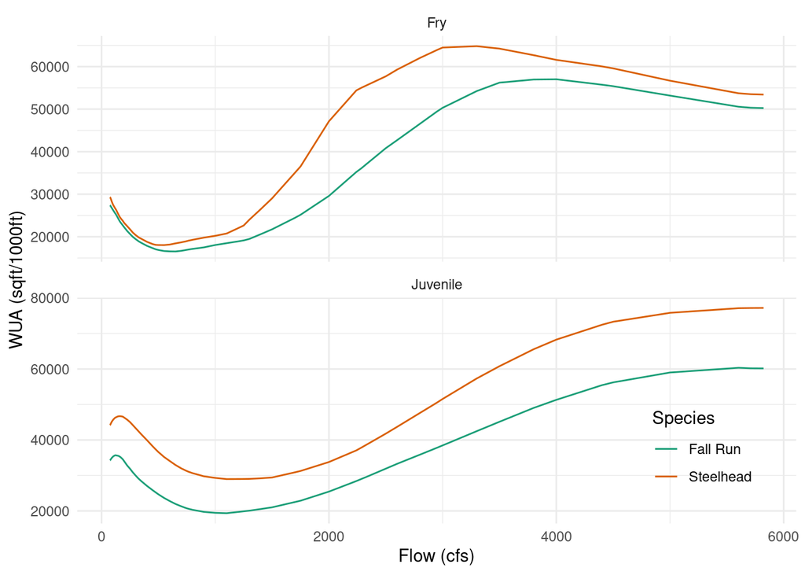

### Adult WUA

[figure not shown]

## Floodplain Rearing Habitat

**Data Source:** [Central Valley Floodplain Evaluation and Delineation (CVFED) HEC-RAS hydraulic model](https://s3-us-west-2.amazonaws.com/cvpiahabitat-r-package/cvpia-sit-model-inputs/TO25-ST8_Tech_Memo_SJR.pdf)

A 25.5 mile portion of the entire mapped rearing extent of 51.8 miles was modeled using Central Valley Floodplain Evaluation and Delineation (CVFED) HEC-RAS hydraulic model. Of the entire mapped rearing extent, 34.6 miles were classified as low gradient and 17.2 miles were classified as high gradient based on a geomorphic analysis of long profile slopes and valley widths. The floodplain area per unit length was determined for the modeled extent and used to approximate areas for the non-modeled extent. The area per unit length was scaled by a factor of 0.1 for the high gradient extent. There was no scaling factor applied to the low gradient extent.

## Floodplain Data

The areas represent total inundated area in acres.

Header Descriptions: flow_cfs = flow in cubic feet per second, FR_floodplain_acres = Fall Run Chinook floodplain acres, ST_floodplain_acres = Steelhead floodplain acres, watershed = section of stream modeled for CVPIA SDM

| flow_cfs | FR_floodplain_acres | ST_floodplain_acres | watershed |
| --- | --- | --- | --- |
| 1250 | 0.00 | 0.00 | Merced River |
| 1500 | 13.90 | 13.90 | Merced River |
| 1750 | 50.29 | 50.29 | Merced River |
| 2000 | 87.17 | 87.17 | Merced River |
| 2500 | 175.96 | 175.96 | Merced River |

*… with 13 more rows*

## Floodplain Plot

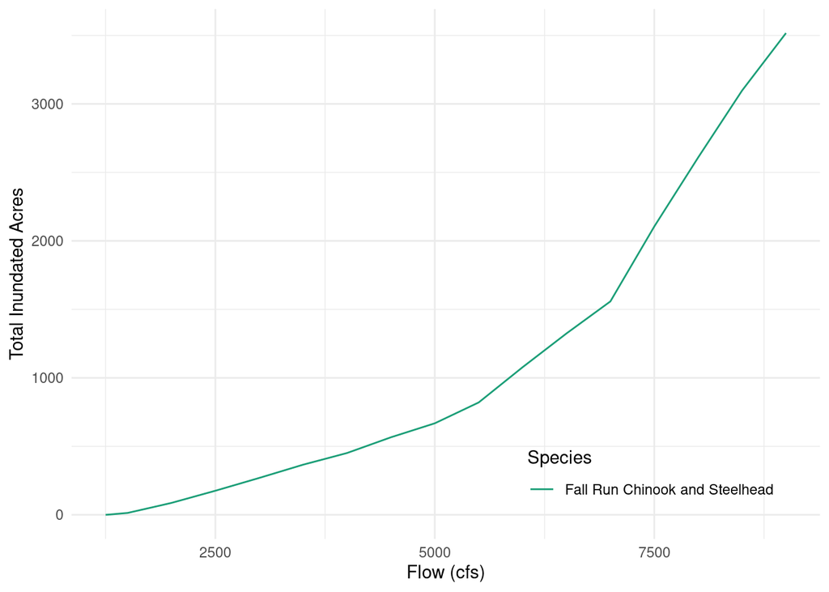